# Netflix catalogue analysis

### Author: Pietro Tegon

### Introduction

In this project, I aim to analyze the characteristics and patterns within Netflix's extensive catalog of movies and TV series to uncover key trends and insights. By examining various metrics such as ratings, hours viewed, genres, networks, and release years, I would like to understand the factors contributing to content success on the platform. Through visualizations and data-driven insights, I will explore the relationship between popularity and quality, the diversity of genres, and the impact of runtime and episode counts on ratings. These findings offer actionable recommendations for Netflix and content creators to optimize their offerings and cater to diverse audience preferences in a competitive streaming market.

### Data sources

1. netflix_titles.csv: https://www.kaggle.com/datasets/rahulvyasm/netflix-movies-and-tv-shows
2. total_netflix_2023 new.csv: https://www.kaggle.com/datasets/willianoliveiragibin/netlifx-hour-2023/data
3. TV_show_data (2).csv : https://www.kaggle.com/datasets/oleksiimartusiuk/1500-tv-shows-ranked

### Project overview

The project will be divided in four parts:

- Part 1: Installing necessary modules
- Part 2: Data cleaning
- Part 3: Data combining and reshaping
- Part 4: Data analisys and visualization

## Part 1 - Installing necessary modules

```python
%pip install pandas
%pip install numpy
%pip install matplotlib
%pip install seaborn
```

In oredr to use the libraries, I will also need to import them

```python
import pandas as pd  # Library for data manipulation and analysis (e.g., handling tabular data with DataFrames)

import numpy as np  # Library for numerical computing and handling arrays/matrices efficiently

import matplotlib.pyplot as plt  # Core plotting library for creating static, interactive, and animated visualizations

import seaborn as sns  # High-level visualization library built on top of matplotlib for creating informative and attractive plots

import ast  # Standard library for safely evaluating and processing Python expressions or code structures

import re  # Library for working with regular expressions for pattern matching and text manipulation

import warnings  # Standard library to manage and suppress warning messages in Python

warnings.filterwarnings('ignore')  # Suppress unnecessary warnings to declutter the output
```

## Part 2 - Data cleaning

**First dataset: "netflix_titles.csv"**

```python
netflix_raw = pd.read_csv('netflix_titles.csv')

netflix_raw.head()
```

|  | show_id | type | title | director | cast | country | date_added | release_year | rating | duration | listed_in | description |
| --- | --- | --- | --- | --- | --- | --- | --- | --- | --- | --- | --- | --- |
| 0 | s1 | Movie | Dick Johnson Is Dead | Kirsten Johnson | NaN | United States | September 25, 2021 | 2020 | PG-13 | 90 min | Documentaries | As her father nears the end of his life, filmm... |
| 1 | s2 | TV Show | Blood & Water | NaN | Ama Qamata, Khosi Ngema, Gail Mabalane, Thaban... | South Africa | September 24, 2021 | 2021 | TV-MA | 2 Seasons | International TV Shows, TV Dramas, TV Mysteries | After crossing paths at a party, a Cape Town t... |
| 2 | s3 | TV Show | Ganglands | Julien Leclercq | Sami Bouajila, Tracy Gotoas, Samuel Jouy, Nabi... | NaN | September 24, 2021 | 2021 | TV-MA | 1 Season | Crime TV Shows, International TV Shows, TV Act... | To protect his family from a powerful drug lor... |
| 3 | s4 | TV Show | Jailbirds New Orleans | NaN | NaN | NaN | September 24, 2021 | 2021 | TV-MA | 1 Season | Docuseries, Reality TV | Feuds, flirtations and toilet talk go down amo... |
| 4 | s5 | TV Show | Kota Factory | NaN | Mayur More, Jitendra Kumar, Ranjan Raj, Alam K... | India | September 24, 2021 | 2021 | TV-MA | 2 Seasons | International TV Shows, Romantic TV Shows, TV ... | In a city of coaching centers known to train I... |

```python
# Dropping the specified columns
columns_to_drop = ['show_id', 'date_added', 'rating', 'description']
netflix_raw = netflix_raw.drop(columns=columns_to_drop)

# Display the first few rows of the updated DataFrame to verify
netflix_raw.head()
```

|  | type | title | director | cast | country | release_year | duration | listed_in |
| --- | --- | --- | --- | --- | --- | --- | --- | --- |
| 0 | Movie | Dick Johnson Is Dead | Kirsten Johnson | NaN | United States | 2020 | 90 min | Documentaries |
| 1 | TV Show | Blood & Water | NaN | Ama Qamata, Khosi Ngema, Gail Mabalane, Thaban... | South Africa | 2021 | 2 Seasons | International TV Shows, TV Dramas, TV Mysteries |
| 2 | TV Show | Ganglands | Julien Leclercq | Sami Bouajila, Tracy Gotoas, Samuel Jouy, Nabi... | NaN | 2021 | 1 Season | Crime TV Shows, International TV Shows, TV Act... |
| 3 | TV Show | Jailbirds New Orleans | NaN | NaN | NaN | 2021 | 1 Season | Docuseries, Reality TV |
| 4 | TV Show | Kota Factory | NaN | Mayur More, Jitendra Kumar, Ranjan Raj, Alam K... | India | 2021 | 2 Seasons | International TV Shows, Romantic TV Shows, TV ... |

```python
# Count the number of NaN values in each column
nan_counts = netflix_raw.isna().sum()

# Display the result
print(nan_counts)
```

```
type               0
title              0
director        2634
cast             825
country          831
release_year       0
duration           3
listed_in          0
dtype: int64
```

```python
# Dropping rows where the 'cast' column has NaN values
netflix_raw = netflix_raw.dropna(subset=['cast'])

# Display the first few rows of the updated DataFrame to verify
netflix_raw.head()
```

|  | type | title | director | cast | country | release_year | duration | listed_in |
| --- | --- | --- | --- | --- | --- | --- | --- | --- |
| 1 | TV Show | Blood & Water | NaN | Ama Qamata, Khosi Ngema, Gail Mabalane, Thaban... | South Africa | 2021 | 2 Seasons | International TV Shows, TV Dramas, TV Mysteries |
| 2 | TV Show | Ganglands | Julien Leclercq | Sami Bouajila, Tracy Gotoas, Samuel Jouy, Nabi... | NaN | 2021 | 1 Season | Crime TV Shows, International TV Shows, TV Act... |
| 4 | TV Show | Kota Factory | NaN | Mayur More, Jitendra Kumar, Ranjan Raj, Alam K... | India | 2021 | 2 Seasons | International TV Shows, Romantic TV Shows, TV ... |
| 5 | TV Show | Midnight Mass | Mike Flanagan | Kate Siegel, Zach Gilford, Hamish Linklater, H... | NaN | 2021 | 1 Season | TV Dramas, TV Horror, TV Mysteries |
| 6 | Movie | My Little Pony: A New Generation | Robert Cullen, José Luis Ucha | Vanessa Hudgens, Kimiko Glenn, James Marsden, ... | NaN | 2021 | 91 min | Children & Family Movies |

Dropping the rows where country is a NaN would just take away some valuable data and the fact that a value under 'country' is not a problem, since the content origin it's not my primary concern. Dropping the rows where the 'director' value is a NaN would mean taking out more than a third of the dataset, so I cannot do that.

```python
# Convert the 'cast' and 'listed_in' columns into lists by splitting on commas
netflix_raw['cast'] = netflix_raw['cast'].apply(lambda x: x.split(', ') if pd.notna(x) else [])
netflix_raw['listed_in'] = netflix_raw['listed_in'].apply(lambda x: x.split(', ') if pd.notna(x) else [])

# Display the first few rows to verify
netflix_raw.head()
```

|  | type | title | director | cast | country | release_year | duration | listed_in |
| --- | --- | --- | --- | --- | --- | --- | --- | --- |
| 1 | TV Show | Blood & Water | NaN | [Ama Qamata, Khosi Ngema, Gail Mabalane, Thaba... | South Africa | 2021 | 2 Seasons | [International TV Shows, TV Dramas, TV Mysteries] |
| 2 | TV Show | Ganglands | Julien Leclercq | [Sami Bouajila, Tracy Gotoas, Samuel Jouy, Nab... | NaN | 2021 | 1 Season | [Crime TV Shows, International TV Shows, TV Ac... |
| 4 | TV Show | Kota Factory | NaN | [Mayur More, Jitendra Kumar, Ranjan Raj, Alam ... | India | 2021 | 2 Seasons | [International TV Shows, Romantic TV Shows, TV... |
| 5 | TV Show | Midnight Mass | Mike Flanagan | [Kate Siegel, Zach Gilford, Hamish Linklater, ... | NaN | 2021 | 1 Season | [TV Dramas, TV Horror, TV Mysteries] |
| 6 | Movie | My Little Pony: A New Generation | Robert Cullen, José Luis Ucha | [Vanessa Hudgens, Kimiko Glenn, James Marsden,... | NaN | 2021 | 91 min | [Children & Family Movies] |

```python
# Extract the numeric part from the 'duration' column
netflix_raw['duration'] = netflix_raw['duration'].str.extract('(\d+)').astype(float)

# Display the first few rows to verify
netflix_raw[['duration']].head()
```

|  | duration |
| --- | --- |
| 1 | 2.0 |
| 2 | 1.0 |
| 4 | 2.0 |
| 5 | 1.0 |
| 6 | 91.0 |

```python
# Turn the values in the 'country' column into lists
netflix_raw['country'] = netflix_raw['country'].apply(
    lambda x: x.split(', ') if isinstance(x, str) else []
)

# Display the first few rows to verify
netflix_raw[['country']].head()
```

|  | country |
| --- | --- |
| 1 | [South Africa] |
| 2 | [] |
| 4 | [India] |
| 5 | [] |
| 6 | [] |

**Second dataset: "total_netflix_2023 new.csv"**

```python
netflix_ratings = pd.read_csv('total_netflix_2023 new.csv')

netflix_ratings.head()
```

|  | Title | Available Globally? | Release Date | Hours Viewed | Number of Ratings | Rating | Genre | Key Words | Description |
| --- | --- | --- | --- | --- | --- | --- | --- | --- | --- |
| 0 | The Night Agent: Season 1 | Yes | 2023-03-23 | 812100000 | 7696.0 | 6.0 | Biography, Drama, History | persian empire,empire,5th century b.c.,achaeme... | The film follows headstrong Ginny who meets Su... |
| 1 | Ginny & Georgia: Season 2 | Yes | 2023-01-05 | 665100000 | 5216.0 | 5.7 | Comedy, Drama,Romance | producer,three word title,headstrong,arranged ... | Betrothed against her will to King George, you... |
| 2 | The Glory: Season 1 // 더 글로리: 시즌 1 | Yes | 2022-12-30 | 622800000 | 11869.0 | 8.4 | ['Short'] | prequel,queen,historical,england,queen charlot... | A holiday romantic comedy that captures the ra... |
| 3 | Wednesday: Season 1 | Yes | 2022-11-23 | 507700000 | 50077.0 | 7.4 | ['Drama', 'History', 'Romance'] | christmas,coming out,holidays,lesbian relation... | The film follows headstrong Ginny who meets Su... |
| 4 | Queen Charlotte: A Bridgerton Story | Yes | 2023-05-04 | 503000000 | 45624.0 | 6.6 | ['Comedy', 'Romance'] | telenovela,drug trafficking,cartel,femme fatal... | While fleeing from dangerous assailants, an as... |

```python
# Dropping the specified columns
columns_to_drop = ['Available Globally?', 'Key Words', 'Description']
netflix_ratings = netflix_ratings.drop(columns=columns_to_drop)

# Display the first few rows to verify
netflix_ratings.head()
```

|  | Title | Release Date | Hours Viewed | Number of Ratings | Rating | Genre |
| --- | --- | --- | --- | --- | --- | --- |
| 0 | The Night Agent: Season 1 | 2023-03-23 | 812100000 | 7696.0 | 6.0 | Biography, Drama, History |
| 1 | Ginny & Georgia: Season 2 | 2023-01-05 | 665100000 | 5216.0 | 5.7 | Comedy, Drama,Romance |
| 2 | The Glory: Season 1 // 더 글로리: 시즌 1 | 2022-12-30 | 622800000 | 11869.0 | 8.4 | ['Short'] |
| 3 | Wednesday: Season 1 | 2022-11-23 | 507700000 | 50077.0 | 7.4 | ['Drama', 'History', 'Romance'] |
| 4 | Queen Charlotte: A Bridgerton Story | 2023-05-04 | 503000000 | 45624.0 | 6.6 | ['Comedy', 'Romance'] |

```python
# Convert 'Release Date' to datetime, with errors='coerce' to handle any invalid formats
netflix_ratings['Release Date'] = pd.to_datetime(netflix_ratings['Release Date'], errors='coerce')

# Extract only the year, and replace NaT with NaN if the date couldn't be parsed
netflix_ratings['Release Date'] = netflix_ratings['Release Date'].dt.year

# Display the first few rows to verify
print(netflix_ratings[['Release Date']].head())
```

```
   Release Date
0        2023.0
1        2023.0
2        2022.0
3        2022.0
4        2023.0
```

```python
# Function to safely convert string representations of lists into actual lists
def convert_to_list(x):
    if isinstance(x, str):
        try:
            # Attempt to evaluate the string as a literal Python object (e.g., list, tuple, etc.)
            return ast.literal_eval(x) if x.startswith('[') and x.endswith(']') else x.split(', ')
        except:
            # If it's not a valid list-like string, just split it by commas
            return x.split(', ')
    return x

# Apply the convert_to_list function to the 'Genre' column
netflix_ratings['Genre'] = netflix_ratings['Genre'].apply(convert_to_list)

# Display the first few rows to verify
netflix_ratings.head()
```

|  | Title | Release Date | Hours Viewed | Number of Ratings | Rating | Genre |
| --- | --- | --- | --- | --- | --- | --- |
| 0 | The Night Agent: Season 1 | 2023.0 | 812100000 | 7696.0 | 6.0 | [Biography, Drama, History] |
| 1 | Ginny & Georgia: Season 2 | 2023.0 | 665100000 | 5216.0 | 5.7 | [Comedy, Drama,Romance] |
| 2 | The Glory: Season 1 // 더 글로리: 시즌 1 | 2022.0 | 622800000 | 11869.0 | 8.4 | [Short] |
| 3 | Wednesday: Season 1 | 2022.0 | 507700000 | 50077.0 | 7.4 | [Drama, History, Romance] |
| 4 | Queen Charlotte: A Bridgerton Story | 2023.0 | 503000000 | 45624.0 | 6.6 | [Comedy, Romance] |

**Third dataset: "TV_show_data (2).csv"**

```python
tv_show_data = pd.read_csv('TV_show_data (2).csv')

tv_show_data.head()
```

|  | Name | Summary | Average Runtime | End Date | Premiere Date | Genres | Type | Language | Network | Rating | Schedule (days) | Schedule (time) | Total Seasons | Total Episodes | Character Names | Person Names | Official Site |
| --- | --- | --- | --- | --- | --- | --- | --- | --- | --- | --- | --- | --- | --- | --- | --- | --- | --- |
| 0 | Breaking Bad | Breaking Bad follows protagonist Walter White,... | 60.0 | 2008-01-20 | 2019-10-11 | ['Drama', 'Crime', 'Thriller'] | Scripted | English | AMC | 9.2 | ['Sunday'] | 22:00 | 5 | 62 | 0-Walter White, 1-Jesse Pinkman, 2-Skyler Whit... | 0-Bryan Cranston, 1-Aaron Paul, 2-Anna Gunn, 3... | http://www.amc.com/shows/breaking-bad |
| 1 | Firefly | Five hundred years in the future, a renegade c... | 64.0 | 2002-09-20 | 2002-12-20 | ['Drama', 'Adventure', 'Science-Fiction'] | Scripted | English | FOX | 9.0 | ['Friday'] | 20:00 | 1 | 14 | 0-Captain Malcolm "Mal" Reynolds, 1-Zoe Alleyn... | 0-Nathan Fillion, 1-Gina Torres, 2-Alan Tudyk,... | NaN |
| 2 | Avatar: The Last Airbender | Water. Earth. Fire. Air. Only the Avatar was t... | 30.0 | 2005-02-21 | 2008-07-19 | ['Action', 'Adventure', 'Fantasy'] | Animation | English | Nickelodeon | 8.9 | ['Saturday'] | 11:00 | 3 | 61 | 0-Aang, 1-Katara, 2-Sokka, 3-Zuko, 4-Appa, 5-M... | 0-Zach Tyler, 1-Mae Whitman, 2-Jack De Sena, 3... | https://www.nick.com/shows/avatar |
| 3 | Sherlock | Sherlock Holmes and Dr. John Watson's adventur... | 90.0 | 2010-07-25 | 2017-01-15 | ['Drama', 'Crime', 'Mystery'] | Scripted | English | BBC One | 8.9 | ['Sunday'] | 21:00 | 4 | 12 | 0-Sherlock Holmes, 1-Dr. John Watson | 0-Benedict Cumberbatch, 1-Martin Freeman | http://www.bbc.co.uk/programmes/b018ttws |
| 4 | Attack on Titan | Known in Japan as Shingeki no Kyojin, many yea... | 26.0 | 2013-04-07 | 2023-11-04 | ['Action', 'Adventure', 'Anime', 'Fantasy'] | Animation | Japanese | NHK | 8.9 | ['Saturday'] | 00:10 | 4 | 89 | 0-Mikasa Ackerman, 1-Armin Arlert, 2-Eren Jaeger | 0-Yui Ishikawa, 1-Marina Inoue, 2-Yûki Kaji | http://shingeki.tv/ |

```python
# List of columns to remove
columns_to_remove = ['Average Runtime', 'Summary' , 'End Date', 'Premiere Date', 'Type', 'Language',
                     'Schedule (days)', 'Schedule (time)', 'Character Names', 'Person Names', 'Official Site']

# Drop the columns
tv_show_data = tv_show_data.drop(columns=columns_to_remove)

# Check the result
tv_show_data.head()
```

|  | Name | Genres | Network | Rating | Total Seasons | Total Episodes |
| --- | --- | --- | --- | --- | --- | --- |
| 0 | Breaking Bad | ['Drama', 'Crime', 'Thriller'] | AMC | 9.2 | 5 | 62 |
| 1 | Firefly | ['Drama', 'Adventure', 'Science-Fiction'] | FOX | 9.0 | 1 | 14 |
| 2 | Avatar: The Last Airbender | ['Action', 'Adventure', 'Fantasy'] | Nickelodeon | 8.9 | 3 | 61 |
| 3 | Sherlock | ['Drama', 'Crime', 'Mystery'] | BBC One | 8.9 | 4 | 12 |
| 4 | Attack on Titan | ['Action', 'Adventure', 'Anime', 'Fantasy'] | NHK | 8.9 | 4 | 89 |

## Part 3 - Data combining and reshaping

**First combination: "netflix_raw" and "netflix_ratings"**

```python
# Standardize the values in the 'title' column of netflix_raw and 'Title' column of netflix_ratings
netflix_raw['standardized_title'] = netflix_raw['title'].str.lower().str.replace(r'[^a-z0-9]', '', regex=True)
netflix_ratings['standardized_title'] = netflix_ratings['Title'].str.lower().str.replace(r'[^a-z0-9]', '', regex=True)

# Find matches between the two columns
matches = netflix_raw['standardized_title'].isin(netflix_ratings['standardized_title'])

# Count the number of matches
num_matches = matches.sum()

# Display the number of matches
print(f"Number of matches: {num_matches}")
```

```
Number of matches: 2353
```

```python
# Merge the two datasets on the standardized_title column
merged_data = pd.merge(
    netflix_raw,
    netflix_ratings,
    how='inner',  # Use inner join to keep only matching rows
    left_on='standardized_title',
    right_on='standardized_title'
)



# Display the first few rows of the merged dataset
merged_data.head()
```

|  | type | title | director | cast | country | release_year | duration | listed_in | standardized_title | Title | Release Date | Hours Viewed | Number of Ratings | Rating | Genre |
| --- | --- | --- | --- | --- | --- | --- | --- | --- | --- | --- | --- | --- | --- | --- | --- |
| 0 | Movie | My Little Pony: A New Generation | Robert Cullen, José Luis Ucha | [Vanessa Hudgens, Kimiko Glenn, James Marsden,... | [] | 2021 | 91.0 | [Children & Family Movies] | mylittleponyanewgeneration | My Little Pony: A New Generation | 2018.0 | 7400000 | 38686.0 | 7.8 | [Documentary, Short] |
| 1 | Movie | Sankofa | Haile Gerima | [Kofi Ghanaba, Oyafunmike Ogunlano, Alexandra ... | [United States, Ghana, Burkina Faso, United Ki... | 1993 | 125.0 | [Dramas, Independent Movies, International Mov... | sankofa | Sankofa | NaN | 0 | 2690.0 | 6.1 | [Documentary, Sport] |
| 2 | Movie | The Starling | Theodore Melfi | [Melissa McCarthy, Chris O'Dowd, Kevin Kline, ... | [United States] | 2021 | 104.0 | [Comedies, Dramas] | thestarling | The Starling | 2019.0 | 2900000 | 100.0 | 7.9 | [Documentary] |
| 3 | Movie | Je Suis Karl | Christian Schwochow | [Luna Wedler, Jannis Niewöhner, Milan Peschel,... | [Germany, Czech Republic] | 2021 | 127.0 | [Dramas, International Movies] | jesuiskarl | Je Suis Karl | 2023.0 | 3900000 | 6780.0 | 6.6 | [Animation, Short, Comedy] |
| 4 | Movie | Intrusion | Adam Salky | [Freida Pinto, Logan Marshall-Green, Robert Jo... | [] | 2021 | 94.0 | [Thrillers] | intrusion | Intrusion | 2022.0 | 5200000 | 25523.0 | 6.7 | [Animation, Family] |

Since I noticed there were some foreign contents which were written in languages with a different alphabet, I chose to drop those rows.

```python
# Filter rows with alphabetical characters in the 'title' column
rows_to_drop = merged_data[~merged_data['title'].str.contains('[a-zA-Z]', na=False)]

# Count the number of rows being dropped
num_rows_dropped = len(rows_to_drop)

# Drop the rows without alphabetical characters in the 'title' column
netflix_f = merged_data[merged_data['title'].str.contains('[a-zA-Z]', na=False)]

# Display the number of rows dropped
print(f"Number of rows dropped: {num_rows_dropped}")

# Sort netflix_f by 'Hours Viewed' in descending order
netflix_f = netflix_f.sort_values(by='Hours Viewed', ascending=False)

# Filter rows where 'type' is 'Movie'
netflix_f = netflix_f[netflix_f['type'] == 'Movie']

# Display the resulting dataset
netflix_f.head()
```

```
Number of rows dropped: 94
```

|  | type | title | director | cast | country | release_year | duration | listed_in | standardized_title | Title | Release Date | Hours Viewed | Number of Ratings | Rating | Genre |
| --- | --- | --- | --- | --- | --- | --- | --- | --- | --- | --- | --- | --- | --- | --- | --- |
| 637 | Movie | The Magic School Bus Rides Again The Frizz Con... | Richard Weston | [Kate McKinnon, Roman Lutterotti, Mikaela Blak... | [Canada] | 2020 | 46.0 | [Children & Family Movies] | themagicschoolbusridesagainthefrizzconnection | The Magic School Bus Rides Again The Frizz Con... | 2023.0 | 99900000 | 535.0 | 5.7 | [Adventure, Drama, Romance] |
| 2168 | Movie | He's Out There | Quinn Lasher | [Yvonne Strahovski, Anna Pniowsky, Abigail Pni... | [United States] | 2018 | 89.0 | [Horror Movies, Thrillers] | hesoutthere | He's Out There | 2018.0 | 9900000 | 56.0 | 9.3 | [Short] |
| 1502 | Movie | Heneral Luna | Jerrold Tarog | [John Arcilla, Mon Confiado, Arron Villaflor, ... | [Philippines] | 2015 | 118.0 | [Dramas, International Movies] | heneralluna | Heneral Luna | 2019.0 | 9800000 | 10936.0 | 6.6 | [Crime, Drama, Mystery] |
| 692 | Movie | High & Low The Red Rain | Yudai Yamaguchi | [Takahiro, Hiroomi Tosaka, Takumi Saitoh, Miyu... | [Japan] | 2016 | 111.0 | [Action & Adventure, International Movies] | highlowtheredrain | High & Low The Red Rain | 2021.0 | 9800000 | 8953.0 | 6.8 | [Animation, Adventure, Comedy] |
| 262 | Movie | Sweet & Sour | Lee Kae-byeok | [Jang Ki-yong, Chae Soo-bin, Jung Soo-jung] | [South Korea] | 2021 | 103.0 | [Comedies, International Movies, Romantic Movies] | sweetsour | Sweet & Sour // 새콤달콤 | 2022.0 | 9800000 | 231.0 | 6.3 | [Reality-TV] |

```python
# List of columns to remove since they are not of my interest or they are doubles
columns_to_remove = ['listed_in', 'standardized_title' , 'Title', 'Release Date' , 'type']

# Drop the columns
movies = netflix_f.drop(columns=columns_to_remove)

# Check the result
movies.head()
```

|  | title | director | cast | country | release_year | duration | Hours Viewed | Number of Ratings | Rating | Genre |
| --- | --- | --- | --- | --- | --- | --- | --- | --- | --- | --- |
| 637 | The Magic School Bus Rides Again The Frizz Con... | Richard Weston | [Kate McKinnon, Roman Lutterotti, Mikaela Blak... | [Canada] | 2020 | 46.0 | 99900000 | 535.0 | 5.7 | [Adventure, Drama, Romance] |
| 2168 | He's Out There | Quinn Lasher | [Yvonne Strahovski, Anna Pniowsky, Abigail Pni... | [United States] | 2018 | 89.0 | 9900000 | 56.0 | 9.3 | [Short] |
| 1502 | Heneral Luna | Jerrold Tarog | [John Arcilla, Mon Confiado, Arron Villaflor, ... | [Philippines] | 2015 | 118.0 | 9800000 | 10936.0 | 6.6 | [Crime, Drama, Mystery] |
| 692 | High & Low The Red Rain | Yudai Yamaguchi | [Takahiro, Hiroomi Tosaka, Takumi Saitoh, Miyu... | [Japan] | 2016 | 111.0 | 9800000 | 8953.0 | 6.8 | [Animation, Adventure, Comedy] |
| 262 | Sweet & Sour | Lee Kae-byeok | [Jang Ki-yong, Chae Soo-bin, Jung Soo-jung] | [South Korea] | 2021 | 103.0 | 9800000 | 231.0 | 6.3 | [Reality-TV] |

**Second combination: "tv_show_data" and "netflix_series"**

Since I already have a movie dataframe, I can now create one about TV Series.

```python
# Filter rows where 'type' is 'TV Series'
netflix_series = netflix_raw[netflix_raw['type'] == 'TV Show']

# Optionally, display the number of rows
print(f"Number of TV Series: {len(netflix_series)}")

# Display the filtered rows
netflix_series.head()
```

```
Number of TV Series: 2326
```

|  | type | title | director | cast | country | release_year | duration | listed_in | standardized_title |
| --- | --- | --- | --- | --- | --- | --- | --- | --- | --- |
| 1 | TV Show | Blood & Water | NaN | [Ama Qamata, Khosi Ngema, Gail Mabalane, Thaba... | [South Africa] | 2021 | 2.0 | [International TV Shows, TV Dramas, TV Mysteries] | bloodwater |
| 2 | TV Show | Ganglands | Julien Leclercq | [Sami Bouajila, Tracy Gotoas, Samuel Jouy, Nab... | [] | 2021 | 1.0 | [Crime TV Shows, International TV Shows, TV Ac... | ganglands |
| 4 | TV Show | Kota Factory | NaN | [Mayur More, Jitendra Kumar, Ranjan Raj, Alam ... | [India] | 2021 | 2.0 | [International TV Shows, Romantic TV Shows, TV... | kotafactory |
| 5 | TV Show | Midnight Mass | Mike Flanagan | [Kate Siegel, Zach Gilford, Hamish Linklater, ... | [] | 2021 | 1.0 | [TV Dramas, TV Horror, TV Mysteries] | midnightmass |
| 8 | TV Show | The Great British Baking Show | Andy Devonshire | [Mel Giedroyc, Sue Perkins, Mary Berry, Paul H... | [United Kingdom] | 2021 | 9.0 | [British TV Shows, Reality TV] | thegreatbritishbakingshow |

```python
# Merge the two datasets on the 'Name' column of tv_show_data and 'title' column of netflix_series
series = pd.merge(tv_show_data, netflix_series, left_on='Name', right_on='title', how='inner')

# Check the result of the merge
series.head()
```

|  | Name | Genres | Network | Rating | Total Seasons | Total Episodes | type | title | director | cast | country | release_year | duration | listed_in | standardized_title |
| --- | --- | --- | --- | --- | --- | --- | --- | --- | --- | --- | --- | --- | --- | --- | --- |
| 0 | Breaking Bad | ['Drama', 'Crime', 'Thriller'] | AMC | 9.2 | 5 | 62 | TV Show | Breaking Bad | NaN | [Bryan Cranston, Aaron Paul, Anna Gunn, Dean N... | [United States] | 2013 | 5.0 | [Crime TV Shows, TV Dramas, TV Thrillers] | breakingbad |
| 1 | Avatar: The Last Airbender | ['Action', 'Adventure', 'Fantasy'] | Nickelodeon | 8.9 | 3 | 61 | TV Show | Avatar: The Last Airbender | NaN | [Zach Tyler, Mae Whitman, Jack De Sena, Dee Br... | [United States] | 2007 | 3.0 | [Classic & Cult TV, Kids' TV, TV Action & Adve... | avatarthelastairbender |
| 2 | Sherlock | ['Drama', 'Crime', 'Mystery'] | BBC One | 8.9 | 4 | 12 | TV Show | Sherlock | NaN | [Benedict Cumberbatch, Martin Freeman, Una Stu... | [United Kingdom, United States] | 2017 | 4.0 | [British TV Shows, Crime TV Shows, Internation... | sherlock |
| 3 | Attack on Titan | ['Action', 'Adventure', 'Anime', 'Fantasy'] | NHK | 8.9 | 4 | 89 | TV Show | Attack on Titan | NaN | [Yuki Kaji, Yui Ishikawa, Marina Inoue, Kisho ... | [Japan] | 2013 | 1.0 | [Anime Series, International TV Shows] | attackontitan |
| 4 | Stargate SG-1 | ['Action', 'Adventure', 'Science-Fiction'] | Syfy | 8.9 | 10 | 213 | TV Show | Stargate SG-1 | NaN | [Richard Dean Anderson, Michael Shanks, Amanda... | [United States, Canada] | 2006 | 10.0 | [Classic & Cult TV, TV Action & Adventure, TV ... | stargatesg1 |

```python
# List of columns to remove
columns_to_remove = ['type', 'title' , 'director', 'duration', 'listed_in', 'standardized_title']

# Drop the columns
series = series.drop(columns=columns_to_remove)

# Check the result
series.head()
```

|  | Name | Genres | Network | Rating | Total Seasons | Total Episodes | cast | country | release_year |
| --- | --- | --- | --- | --- | --- | --- | --- | --- | --- |
| 0 | Breaking Bad | ['Drama', 'Crime', 'Thriller'] | AMC | 9.2 | 5 | 62 | [Bryan Cranston, Aaron Paul, Anna Gunn, Dean N... | [United States] | 2013 |
| 1 | Avatar: The Last Airbender | ['Action', 'Adventure', 'Fantasy'] | Nickelodeon | 8.9 | 3 | 61 | [Zach Tyler, Mae Whitman, Jack De Sena, Dee Br... | [United States] | 2007 |
| 2 | Sherlock | ['Drama', 'Crime', 'Mystery'] | BBC One | 8.9 | 4 | 12 | [Benedict Cumberbatch, Martin Freeman, Una Stu... | [United Kingdom, United States] | 2017 |
| 3 | Attack on Titan | ['Action', 'Adventure', 'Anime', 'Fantasy'] | NHK | 8.9 | 4 | 89 | [Yuki Kaji, Yui Ishikawa, Marina Inoue, Kisho ... | [Japan] | 2013 |
| 4 | Stargate SG-1 | ['Action', 'Adventure', 'Science-Fiction'] | Syfy | 8.9 | 10 | 213 | [Richard Dean Anderson, Michael Shanks, Amanda... | [United States, Canada] | 2006 |

## Part 4 - Data analisys and visualization

### First dataset: movies

The first dataset that will be examined is the one which contains data about movies.

1. **Distribution of Ratings**

[figure not shown]

```python
# Sorting the dataset by 'Rating' for better visualization
movies_sorted = movies.sort_values(by='Rating')

# Plotting the distribution of ratings with sorted data
plt.figure(figsize=(8, 6))
sns.histplot(movies_sorted['Rating'], bins=20, kde=True)
plt.title("Distribution of Movie Ratings (Ordered Data)")
plt.xlabel("Rating")
plt.ylabel("Frequency")

# Adjusting the x-axis ticks for better readability
plt.xticks([0, 20, 40, 60])  # Replace with appropriate reference values based on your dataset's range

plt.show()
```

The distribution appears to follow a near-normal pattern, with most ratings clustered around 6.4. This indicates that Netflix movies are generally rated as average to good but rarely achieve extreme ratings on either end of the spectrum. As a solution, Netflix might focus on identifying what makes a movie stand out for higher ratings to enhance its portfolio's appeal.

2. **Average Rating by Genre**

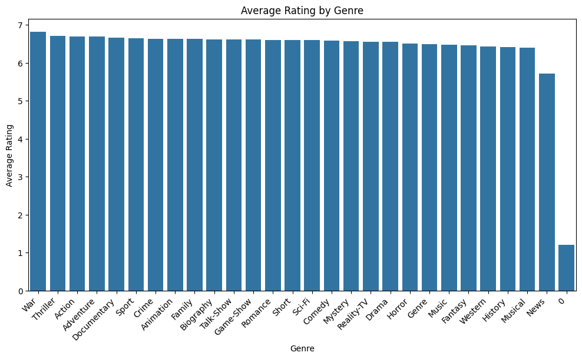

```python
# Ensure 'Rating' is numeric
movies['Rating'] = pd.to_numeric(movies['Rating'], errors='coerce')  # Converts to numeric, setting invalid entries as NaN

# Drop rows with NaN ratings (optional, depends on your analysis goals)
movies = movies.dropna(subset=['Rating'])

# Expand the 'Genre' column into individual rows
movies_exploded = movies.explode('Genre')

# Group by individual genres and calculate the mean rating
genre_ratings = movies_exploded.groupby('Genre')['Rating'].mean().sort_values(ascending=False)

# Plotting the results
plt.figure(figsize=(12, 6))
sns.barplot(x=genre_ratings.index, y=genre_ratings.values)
plt.title("Average Rating by Genre")
plt.xlabel("Genre")
plt.ylabel("Average Rating")
plt.xticks(rotation=45, ha='right')
plt.show()
```

The uniformity in ratings across genres suggests that quality control is consistent, but it also points to a lack of standout genres outperforming others. Netflix might explore investing in genres that consistently perform better globally (e.g., thrillers or documentaries) to maximize viewer satisfaction.

3. **Movies Released Over Time**

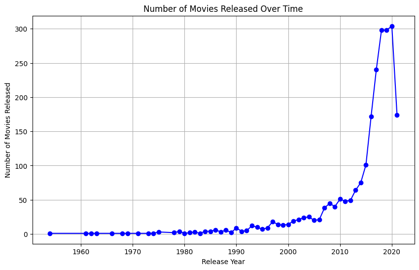

```python
release_year_counts = movies['release_year'].value_counts().sort_index()

plt.figure(figsize=(10, 6))
release_year_counts.plot(kind='line', marker='o', linestyle='-', color='b')
plt.title("Number of Movies Released Over Time")
plt.xlabel("Release Year")
plt.ylabel("Number of Movies Released")
plt.grid(True)
plt.show()
```

4. **Correlation Between Rating and Hours Viewed**

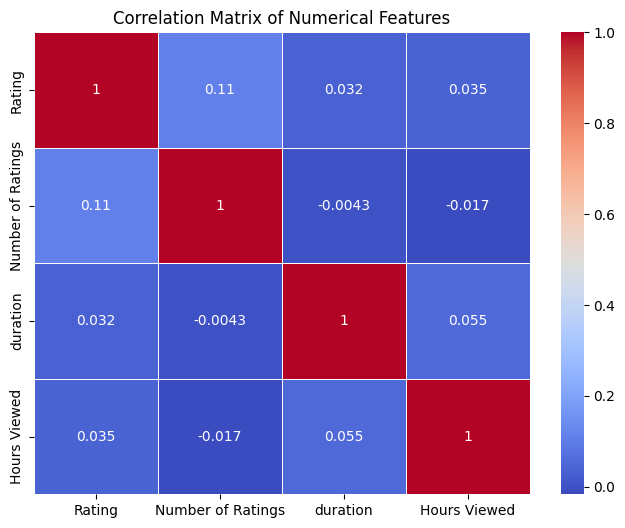

```python
correlation_matrix = movies[['Rating', 'Number of Ratings', 'duration', 'Hours Viewed']].corr()

plt.figure(figsize=(8, 6))
sns.heatmap(correlation_matrix, annot=True, cmap='coolwarm', linewidths=0.5)
plt.title("Correlation Matrix of Numerical Features")
plt.show()
```

The weak correlations across variables indicate minimal direct relationships between features like "Rating," "Number of Ratings," "Duration," and "Hours Viewed." This could imply that user engagement and ratings are influenced by subjective preferences rather than quantifiable factors like runtime or popularity. Netflix could use this insight to improve personalized recommendations based on viewer behavior.

5. **Average Rating by Hours Viewed Range**

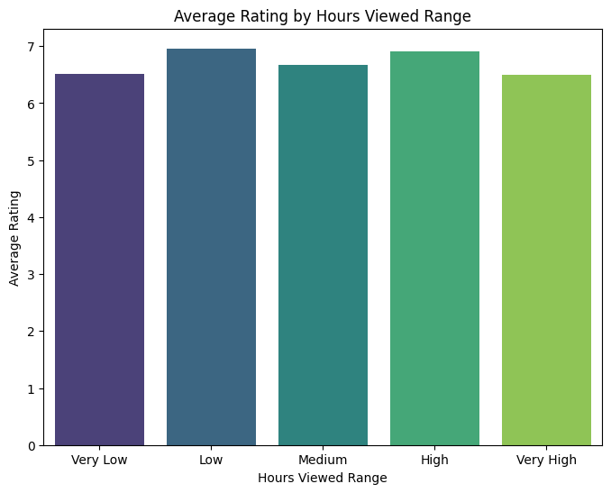

```python
# Ensure 'Hours Viewed' is numeric
movies['Hours Viewed'] = pd.to_numeric(movies['Hours Viewed'], errors='coerce')

# Drop rows with missing or invalid 'Hours Viewed'
movies = movies.dropna(subset=['Hours Viewed'])

# Define bins for Hours Viewed
bins = pd.cut(movies['Hours Viewed'], bins=5, labels=['Very Low', 'Low', 'Medium', 'High', 'Very High'])

# Group by bins and calculate mean rating
binned_data = movies.groupby(bins)['Rating'].mean()

# Plot
plt.figure(figsize=(8, 6))
sns.barplot(x=binned_data.index, y=binned_data.values, palette='viridis')
plt.title("Average Rating by Hours Viewed Range")
plt.xlabel("Hours Viewed Range")
plt.ylabel("Average Rating")
plt.show()
```

The ratings are fairly consistent across different viewing ranges, with only slight variations. Interestingly, the "Very High" hours viewed range shows a marginal dip in average ratings compared to "Low," "Medium," and "High" ranges. This could suggest that highly popular movies (with "Very High" viewing hours) are not necessarily the highest-rated, potentially because they appeal to a broader audience with diverse preferences, leading to mixed reviews.

6. **Top 5 Movies by Rating and Hours Viewed**

```python
# Top 5 movies by Rating
top_5_by_rating = movies[['title', 'Rating', 'Hours Viewed']].sort_values(by='Rating', ascending=False).head(5)

# Top 5 movies by Hours Viewed
top_5_by_hours = movies[['title', 'Rating', 'Hours Viewed']].sort_values(by='Hours Viewed', ascending=False).head(5)

# Display the results
print("Top 5 Movies by Rating:")
print(top_5_by_rating[['title', 'Rating']])

print("\nTop 5 Movies by Hours Viewed:")
print(top_5_by_hours[['title', 'Hours Viewed']])
```

```
Top 5 Movies by Rating:
                                    title  Rating
2440              XXX: State of the Union    10.0
485                               The Dig     9.9
120   Shiny_Flakes: The Teenage Drug Lord     9.7
1149                  The Garden of Words     9.7
1303                          Dry Martina     9.4

Top 5 Movies by Hours Viewed:
                         title  Hours Viewed
1734              Step Sisters     266200000
428        The Yin Yang Master     221100000
662   StarBeam: Halloween Hero     205500000
1066                Steve Jobs     200700000
400                 Wild Child     200700000
```

Top 5 Movies by Rating

- The highest-rated movies include XXX: State of the Union, The Dig, and Shiny_Flakes: The Teenage Drug Lord, among others, with ratings between 9.4 and 10.0.
- These movies likely appeal to niche audiences, as extremely high ratings are often the result of strong engagement from a targeted viewer group.
- The presence of diverse genres, such as documentaries (Shiny_Flakes) and animated films (The Garden of Words), suggests that top ratings are not limited to one particular genre but are spread across varied storytelling formats.

Top 5 Movies by Hours Viewed

- The movies with the most hours viewed, such as Step Sisters, The Yin Yang Master, and StarBeam: Halloween Hero, all have hours exceeding 200 million.
- These films may not necessarily have the highest ratings, suggesting they gained popularity through mass appeal, strong marketing campaigns, or suitability for a broad audience, such as family-friendly or action-packed themes.
- Interestingly, there is no overlap between the top-rated and most-viewed lists, reinforcing that popularity does not always correlate with perceived quality.

### Second dataset: series

The second dataset that will be analyzed is about series or tv shows available on netflix.

1. **Distribution of Ratings**

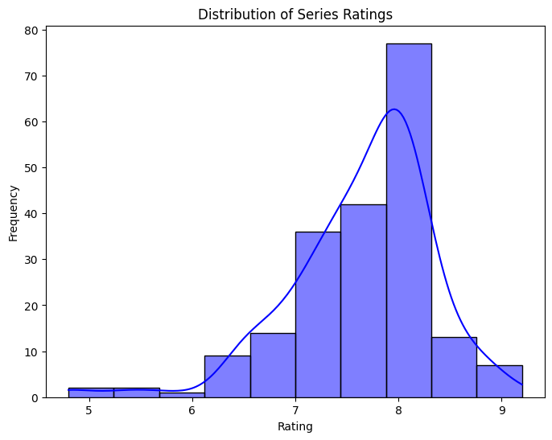

```python
plt.figure(figsize=(8, 6))
sns.histplot(series['Rating'], bins=10, kde=True, color='blue')
plt.title("Distribution of Series Ratings")
plt.xlabel("Rating")
plt.ylabel("Frequency")
plt.show()
```

2. **Average Rating by Network**

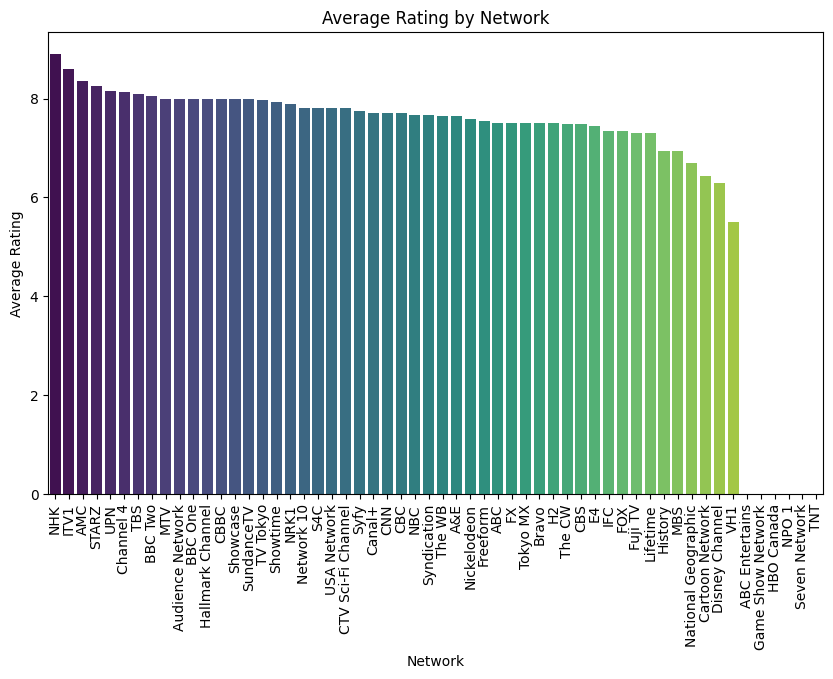

```python
avg_rating_by_network = series.groupby('Network')['Rating'].mean().sort_values(ascending=False)

plt.figure(figsize=(10, 6))
sns.barplot(x=avg_rating_by_network.index, y=avg_rating_by_network.values, palette='viridis')
plt.title("Average Rating by Network")
plt.xlabel("Network")
plt.ylabel("Average Rating")
plt.xticks(rotation=90)
plt.show()
```

3. **Number of Series per Genre**

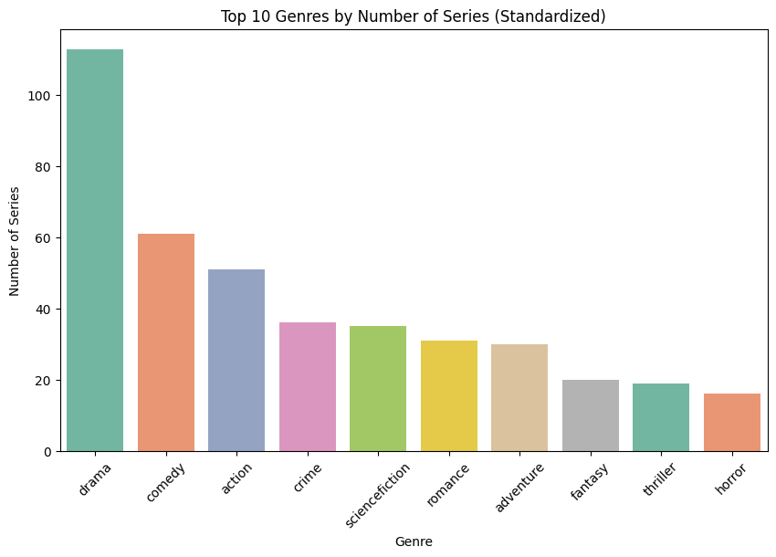

```python
# If genres are in lists (e.g., ['Drama', 'Comedy']), we need to explode them into individual entries
genres_exploded = series['Genres'].str.split(',').explode().str.strip()

# Standardize genre names: remove special characters, lowercase, and strip extra spaces
genres_exploded = genres_exploded.apply(lambda x: re.sub(r'[^a-zA-Z0-9\s]', '', x).lower())

# Count occurrences of each genre
genre_counts = genres_exploded.value_counts()

# Get the top 10 genres
top_10_genres = genre_counts.head(10)

# Plot
plt.figure(figsize=(10, 6))
sns.barplot(x=top_10_genres.index, y=top_10_genres.values, palette='Set2')
plt.title("Top 10 Genres by Number of Series (Standardized)")
plt.xlabel("Genre")
plt.ylabel("Number of Series")
plt.xticks(rotation=45)
plt.show()
```

Drama dominates as the most common genre, followed by comedy, action, and crime. Genres like horror and thriller are significantly underrepresented. The dominance of drama and comedy indicates a focus on genres with mass appeal and storytelling versatility. The underrepresentation of genres like horror and thriller suggests untapped opportunities for Netflix to diversify its catalog and attract niche audiences. Targeting underrepresented genres could also help Netflix stand out in a crowded streaming market.

4. **Total Episodes vs. Rating**

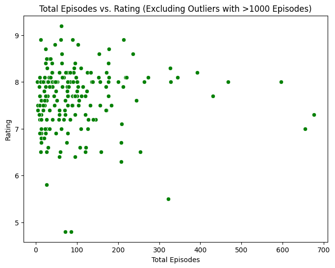

```python
# Filter out rows where Total Episodes > 1000
filtered_series = series[series['Total Episodes'] <= 1000]

# Plot the scatterplot
plt.figure(figsize=(8, 6))
sns.scatterplot(x='Total Episodes', y='Rating', data=filtered_series, color='green')
plt.title("Total Episodes vs. Rating (Excluding Outliers with >1000 Episodes)")
plt.xlabel("Total Episodes")
plt.ylabel("Rating")
plt.show()
```

```python
# Step 1: Sort the series dataset by 'Rating' in descending order
top_10_series = series.nlargest(10, 'Rating')[['Name', 'Rating']]

# Display the result
print(top_10_series)
```

```
                             Name  Rating
0                    Breaking Bad     9.2
1      Avatar: The Last Airbender     8.9
2                        Sherlock     8.9
3                 Attack on Titan     8.9
4                   Stargate SG-1     8.9
5              Person of Interest     8.8
6                   Downton Abbey     8.8
7  Star Trek: The Next Generation     8.7
8                    The IT Crowd     8.7
9                         Friends     8.6
```

## Conclusion

The findings of this project provide valuable insights into the dynamics of Netflix's movie and TV series offerings:

Netflix could invest in high-quality productions in underrepresented genres or niche categories to attract untapped audiences. By analyzing the attributes of critically successful and highly-viewed content, Netflix can refine its strategy for producing and promoting new releases. Personalized recommendations based on user behavior and preferences could significantly enhance engagement and satisfaction, bridging the gap between popularity and quality. In conclusion, this project highlights the importance of balancing mass appeal with critical acclaim and maintaining a diverse yet high-quality catalog. As the streaming landscape grows increasingly competitive, leveraging these insights could position Netflix to sustain its leadership in the industry while delivering exceptional content that resonates with audiences worldwide.